# Machine Learning Course Project

Benjamin Lim

20/01/2018

The objective of this project is to built a predictive model that determines the manner in which a participant completed a single type of exercise - the unilateral dumbbell biceps curl. Six male participants between 20 - 28 years with little weight lifting experience were selected as subjects to perform the exercise in one of five different ways. The five ways are: * Exactly according to specification (Class A) * Throwing the the elbows to the front (Class B) * Lifting the dumbbell only halfway (Class C) * lowering the dumbbell only halfway (Class D), and * Throwing the hips to the front (Class E). Class A corresponds to the correct execution while the other 4 classes are common mistakes made.

Data recording was done using four 9-degrees of freedom Razor inertial measurement units (IMU), which were attached to the dumbbell, wrist, upper arm, and waist. To extract the features in the data set, the authors used a sliding window approach with different lengths of 0.5 to 2.5 seconds with 0.5 seconds overlap. In each step of the window, they calculated features on the Euler angles (roll, pitch and yaw), as well as the raw accelerometer, gyroscope and magnetometer readings. For the Euler angles of each of the four sensors they calculated eight features: mean, variance, standard deviation, max, min, amplitude, kurtosis and skew- ness, generating 96 derived feature sets.

## Exploratory Analysis

We will first download and read in the data using the `read.csv` command.

```r
library(ggplot2)
library(caret)
download.file("https://d396qusza40orc.cloudfront.net/predmachlearn/pml-training.csv", "pml-training.csv")
quality <- read.csv("./pml-training.csv", na.strings = c("NA", ""))
dim(quality)
```

```
## [1] 19622   160
```

Using the `dim()` command, we see that the data consists of a large 19622 rows by 160 column dataframe. To help scope our analysis, we will use the `is.na()` function to identify suitable columns to keep for our analysis.

```r
apply(is.na(quality),2,mean) -> nacols
table(nacols)
```

```
## nacols
##                 0 0.979308938946081
##                60               100
```

We see that 100 columns have more than 97% NAs, these columns will be removed from the dataframe to be used in building the model. Further unnecessary columns for prediction include `X` (row numbers), “user_name” (subject name), the time stamp columns `raw_timestamp_part_1, raw_timestamp_part_2, cvtd_timestamp`, and `new_window, num_window`, which refer to the sliding window approach used for feature extraction and selection.

```r
quality <- quality[!nacols]
## It so happens that the unnecessary columns are also the first 7 columns in the dataframe
quality <- quality[,-c(1:7)]
```

We should also eliminate variables that have no variance in order to avoid including variables with no impact on model building efficacy. However, none of the predictors have zero or near zero variance, hence we should retain all of them.

```r
nearZeroVar(quality[-53], saveMetrics = T)
```

```
##                      freqRatio percentUnique zeroVar   nzv
## roll_belt             1.101904     6.7781062   FALSE FALSE
## pitch_belt            1.036082     9.3772296   FALSE FALSE
## yaw_belt              1.058480     9.9734991   FALSE FALSE
## total_accel_belt      1.063160     0.1477933   FALSE FALSE
## gyros_belt_x          1.058651     0.7134849   FALSE FALSE
## gyros_belt_y          1.144000     0.3516461   FALSE FALSE
## gyros_belt_z          1.066214     0.8612782   FALSE FALSE
## accel_belt_x          1.055412     0.8357966   FALSE FALSE
## accel_belt_y          1.113725     0.7287738   FALSE FALSE
## accel_belt_z          1.078767     1.5237998   FALSE FALSE
## magnet_belt_x         1.090141     1.6664968   FALSE FALSE
## magnet_belt_y         1.099688     1.5187035   FALSE FALSE
## magnet_belt_z         1.006369     2.3290184   FALSE FALSE
## roll_arm             52.338462    13.5256345   FALSE FALSE
## pitch_arm            87.256410    15.7323412   FALSE FALSE
## yaw_arm              33.029126    14.6570176   FALSE FALSE
## total_accel_arm       1.024526     0.3363572   FALSE FALSE
## gyros_arm_x           1.015504     3.2769341   FALSE FALSE
## gyros_arm_y           1.454369     1.9162165   FALSE FALSE
## gyros_arm_z           1.110687     1.2638875   FALSE FALSE
## accel_arm_x           1.017341     3.9598410   FALSE FALSE
## accel_arm_y           1.140187     2.7367241   FALSE FALSE
## accel_arm_z           1.128000     4.0362858   FALSE FALSE
## magnet_arm_x          1.000000     6.8239731   FALSE FALSE
## magnet_arm_y          1.056818     4.4439914   FALSE FALSE
## magnet_arm_z          1.036364     6.4468454   FALSE FALSE
## roll_dumbbell         1.022388    84.2065029   FALSE FALSE
## pitch_dumbbell        2.277372    81.7449801   FALSE FALSE
## yaw_dumbbell          1.132231    83.4828254   FALSE FALSE
## total_accel_dumbbell  1.072634     0.2191418   FALSE FALSE
## gyros_dumbbell_x      1.003268     1.2282132   FALSE FALSE
## gyros_dumbbell_y      1.264957     1.4167771   FALSE FALSE
## gyros_dumbbell_z      1.060100     1.0498420   FALSE FALSE
## accel_dumbbell_x      1.018018     2.1659362   FALSE FALSE
## accel_dumbbell_y      1.053061     2.3748853   FALSE FALSE
## accel_dumbbell_z      1.133333     2.0894914   FALSE FALSE
## magnet_dumbbell_x     1.098266     5.7486495   FALSE FALSE
## magnet_dumbbell_y     1.197740     4.3012945   FALSE FALSE
## magnet_dumbbell_z     1.020833     3.4451126   FALSE FALSE
## roll_forearm         11.589286    11.0895933   FALSE FALSE
## pitch_forearm        65.983051    14.8557741   FALSE FALSE
## yaw_forearm          15.322835    10.1467740   FALSE FALSE
## total_accel_forearm   1.128928     0.3567424   FALSE FALSE
## gyros_forearm_x       1.059273     1.5187035   FALSE FALSE
## gyros_forearm_y       1.036554     3.7763735   FALSE FALSE
## gyros_forearm_z       1.122917     1.5645704   FALSE FALSE
## accel_forearm_x       1.126437     4.0464784   FALSE FALSE
## accel_forearm_y       1.059406     5.1116094   FALSE FALSE
## accel_forearm_z       1.006250     2.9558659   FALSE FALSE
## magnet_forearm_x      1.012346     7.7667924   FALSE FALSE
## magnet_forearm_y      1.246914     9.5403119   FALSE FALSE
## magnet_forearm_z      1.000000     8.5771073   FALSE FALSE
```

We will now split the data into a training and cross-validation set using `createDataPartition()` in a 70% to 30% ratio respectively.

```r
set.seed(1234)
inTrain <- createDataPartition(y=quality$classe, p = 0.7, list = F)
training <- quality[inTrain, ]
crossval <- quality[-inTrain, ]
```

## Model Building and Selection

For the purposes of building our model, we will use two of the most accurate model-building methods that often win prediction competitions: random forests and boosting with trees. The relative accuracies of both methods will be compared and the best model (taking into account speed, interpretability and accuracy will be used).

### Random Forest model

Random Forest was selected because it automatically selects important variables and is robust to correlated covariates & outliers in general. 10-fold cross validation with half the default number of trees (150) will be used when applying the algorithm in order to save on computing time while maintaining low error.

```r
ctrl <- trainControl(method = "cv", 10)
set.seed(5678)
rfmod <- train(classe~., data = training, method = "rf", trControl = ctrl, ntree = 150)
rfmod
```

```
## Random Forest
##
## 13737 samples
##    52 predictor
##     5 classes: 'A', 'B', 'C', 'D', 'E'
##
## No pre-processing
## Resampling: Cross-Validated (10 fold)
## Summary of sample sizes: 12363, 12363, 12362, 12364, 12365, 12363, ...
## Resampling results across tuning parameters:
##
##   mtry  Accuracy   Kappa
##    2    0.9927931  0.9908829
##   27    0.9940320  0.9924495
##   52    0.9901005  0.9874758
##
## Accuracy was used to select the optimal model using the largest value.
## The final value used for the model was mtry = 27.
```

The performance of the model on the validation set is then computed:

```r
rfpred <- predict(rfmod, crossval[,-53])
rf <- confusionMatrix(crossval$classe, rfpred)
rf
```

```
## Confusion Matrix and Statistics
##
##           Reference
## Prediction    A    B    C    D    E
##          A 1674    0    0    0    0
##          B   10 1128    1    0    0
##          C    0    3 1019    4    0
##          D    0    1    7  955    1
##          E    0    1    4    3 1074
##
## Overall Statistics
##
##                Accuracy : 0.9941
##                  95% CI : (0.9917, 0.9959)
##     No Information Rate : 0.2862
##     P-Value [Acc > NIR] : < 2.2e-16
##
##                   Kappa : 0.9925
##  Mcnemar's Test P-Value : NA
##
## Statistics by Class:
##
##                      Class: A Class: B Class: C Class: D Class: E
## Sensitivity            0.9941   0.9956   0.9884   0.9927   0.9991
## Specificity            1.0000   0.9977   0.9986   0.9982   0.9983
## Pos Pred Value         1.0000   0.9903   0.9932   0.9907   0.9926
## Neg Pred Value         0.9976   0.9989   0.9975   0.9986   0.9998
## Prevalence             0.2862   0.1925   0.1752   0.1635   0.1827
## Detection Rate         0.2845   0.1917   0.1732   0.1623   0.1825
## Detection Prevalence   0.2845   0.1935   0.1743   0.1638   0.1839
## Balanced Accuracy      0.9970   0.9966   0.9935   0.9954   0.9987
```

Accuracy is 0.9940527 and the out of sample error rate is thus 0.0059473.

### Boosting Model

10-fold cross validation will be used when applying the algorithm.

```r
set.seed(5678)
boostmod <- train(classe~., data = training, method = "gbm", trControl = ctrl, verbose = F)
boostmod
```

```
## Stochastic Gradient Boosting
##
## 13737 samples
##    52 predictor
##     5 classes: 'A', 'B', 'C', 'D', 'E'
##
## No pre-processing
## Resampling: Cross-Validated (10 fold)
## Summary of sample sizes: 12363, 12363, 12362, 12364, 12365, 12363, ...
## Resampling results across tuning parameters:
##
##   interaction.depth  n.trees  Accuracy   Kappa
##   1                   50      0.7500157  0.6830747
##   1                  100      0.8179354  0.7696185
##   1                  150      0.8538970  0.8151476
##   2                   50      0.8545526  0.8157427
##   2                  100      0.9034000  0.8777582
##   2                  150      0.9306255  0.9122167
##   3                   50      0.8930627  0.8646175
##   3                  100      0.9436553  0.9286898
##   3                  150      0.9620014  0.9519187
##
## Tuning parameter 'shrinkage' was held constant at a value of 0.1
##
## Tuning parameter 'n.minobsinnode' was held constant at a value of 10
## Accuracy was used to select the optimal model using the largest value.
## The final values used for the model were n.trees = 150,
##  interaction.depth = 3, shrinkage = 0.1 and n.minobsinnode = 10.
```

The performance of this model on the validation set:

```r
boostpred <- predict(boostmod, crossval[,-53])
bst <- confusionMatrix(crossval$classe, boostpred)
bst
```

```
## Confusion Matrix and Statistics
##
##           Reference
## Prediction    A    B    C    D    E
##          A 1651   15    4    2    2
##          B   43 1066   25    4    1
##          C    0   22  992   11    1
##          D    0    8   23  924    9
##          E    1   12   14   17 1038
##
## Overall Statistics
##
##                Accuracy : 0.9636
##                  95% CI : (0.9585, 0.9683)
##     No Information Rate : 0.288
##     P-Value [Acc > NIR] : < 2.2e-16
##
##                   Kappa : 0.954
##  Mcnemar's Test P-Value : 4.728e-07
##
## Statistics by Class:
##
##                      Class: A Class: B Class: C Class: D Class: E
## Sensitivity            0.9740   0.9492   0.9376   0.9645   0.9876
## Specificity            0.9945   0.9847   0.9930   0.9919   0.9909
## Pos Pred Value         0.9863   0.9359   0.9669   0.9585   0.9593
## Neg Pred Value         0.9896   0.9880   0.9864   0.9931   0.9973
## Prevalence             0.2880   0.1908   0.1798   0.1628   0.1786
## Detection Rate         0.2805   0.1811   0.1686   0.1570   0.1764
## Detection Prevalence   0.2845   0.1935   0.1743   0.1638   0.1839
## Balanced Accuracy      0.9843   0.9670   0.9653   0.9782   0.9893
```

Accuracy is 0.9636364 and the out of sample error is 0.0363636.

Given the higher accuracy of the random forest model and the lower estimated out of sample error, we have selected the random forests model.

## Prediction for Test Data

```r
# download and clean-up of data
download.file("https://d396qusza40orc.cloudfront.net/predmachlearn/pml-testing.csv", "pml-testing.csv")
testing <- read.csv("./pml-testing.csv", na.strings = c("NA", ""))
testing <- testing[!nacols]

data.frame(Question = testing$problem_id, Results = predict(rfmod, testing[,8:59]))
```

```
##    Question Results
## 1         1       B
## 2         2       A
## 3         3       B
## 4         4       A
## 5         5       A
## 6         6       E
## 7         7       D
## 8         8       B
## 9         9       A
## 10       10       A
## 11       11       B
## 12       12       C
## 13       13       B
## 14       14       A
## 15       15       E
## 16       16       E
## 17       17       A
## 18       18       B
## 19       19       B
## 20       20       B
```

## Appendix

Figure 1. Showing why optimal number of predictors is 27

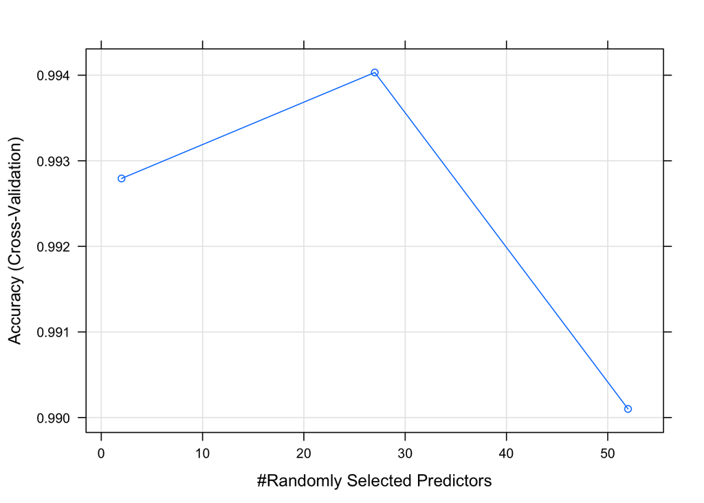

```r
plot(rfmod)
```

Figure 2. Plot of the error rate versus number of trees

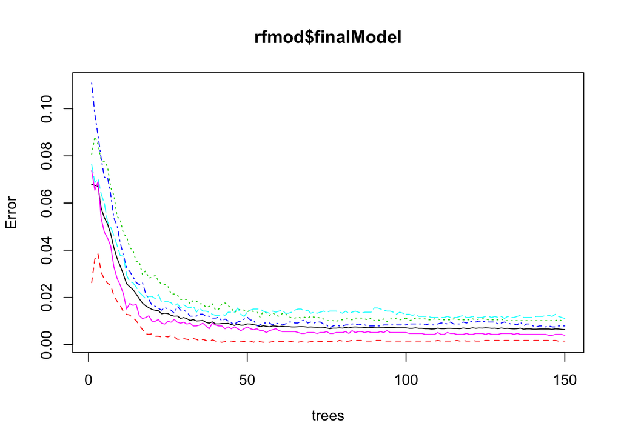

```r
plot(rfmod$finalModel)
```

Figure 3. Top 10 most important variables in random forest model

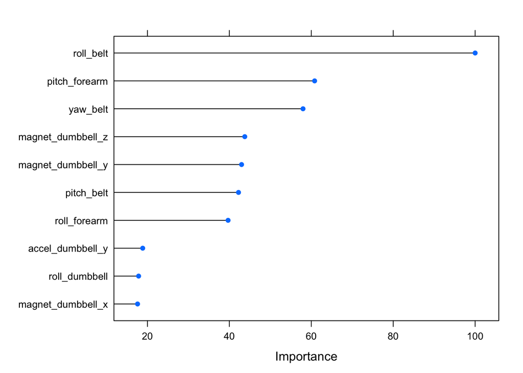

```r
plot(varImp(rfmod), top = 10)
```